# *RMeDPower2*: helping design and analyses of data from repeated measures experiments

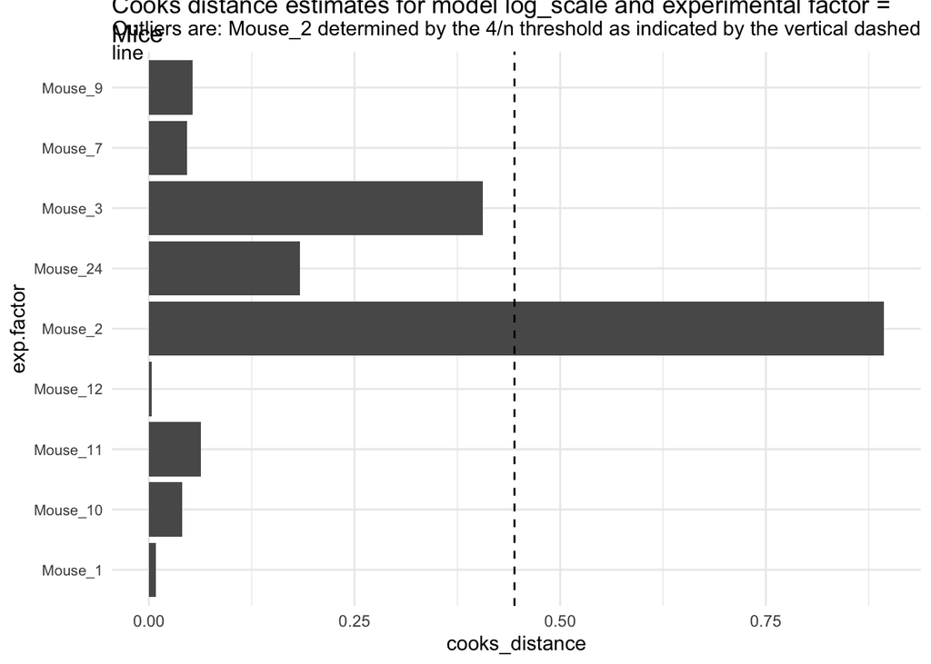

```r
for(i in 1:length(cooks_plots)) {
  print(cooks_plots[[i]])
  cat(sprintf("\n\n\n**Figure %d:**\n\n", plot_no))
  plot_no <- plot_no + 1
}
```

**Figure 91:**

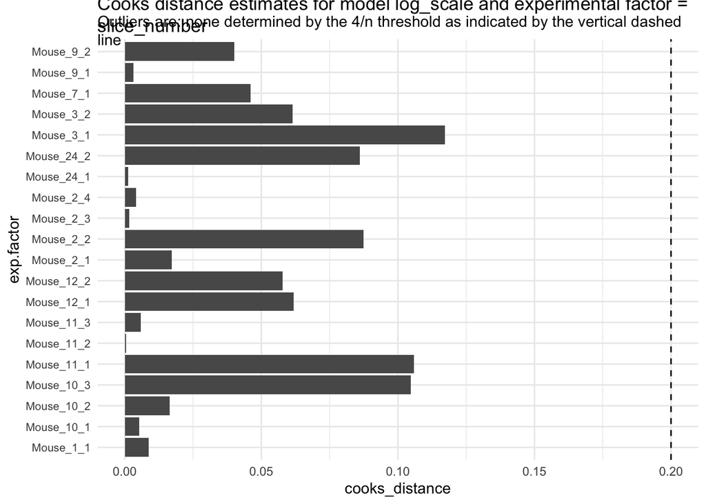

**Figure 92:**

```r
print("Inferred outlier groups are")
```

[1] “Inferred outlier groups are”

```r
print(diagnose_res$inferred_outlier_groups$natural_scale)
```

$Mice [1] “Mouse_2”

$slice_number [1] “Mouse_11_1”

We will work with the model of the electrical responses in the natural scale without outliers

The code also outputs Cook’s distance measures for each cohort and mouse that is intended to capture how influential each of these were in determining the final parameter estimates in the LMM model.

Mouse_2 appears to be an outlier based on its cook’s distance estimate (of 0.90) from the natural scale without outliers model and a 4/n=4/9=0.44 threshold.

We will therefore drop all observations from Mouse_2.

```r
data_update <- diagnose_res$Data_updated
data_update %<>% filter(Mice != "Mouse_2")
design_update <- design
design_update@response_column %<>% paste0(., "_noOutlier")
diagnose_res_update <- diagnoseDataModel(data_update, design_update, model)
```

To identify all the models fit to the data

```r
print(diagnose_res_update$models)
```

```
## [1] "Natural scale" "Log scale"
```

We see that two models were fit to this data - one in the natural scale of negative_action_potential_mV, other in the log scale.

Let us look the basic QC plots for the models fit in the natural scale of the responses.

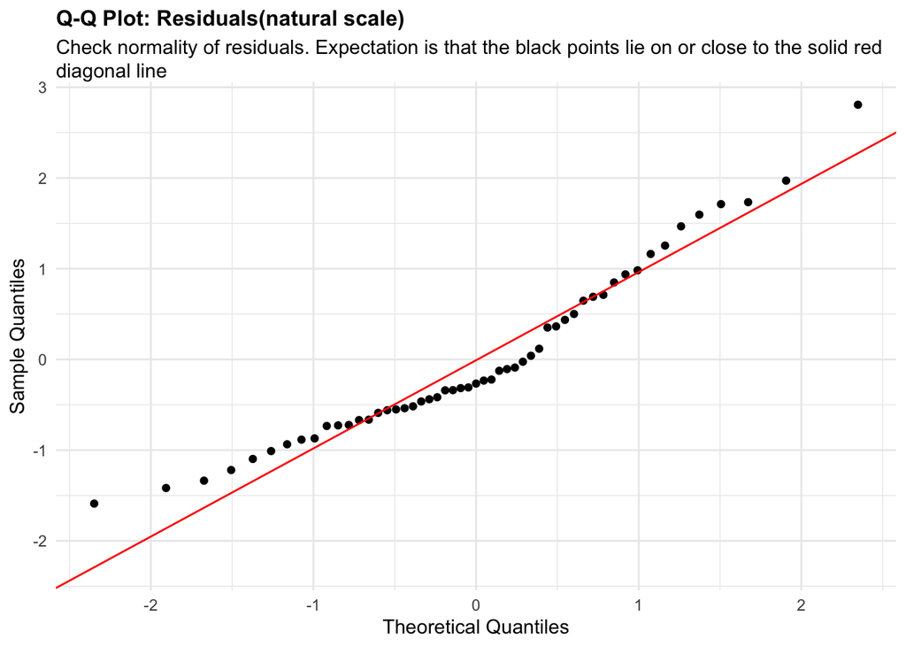

```r
plots <- diagnose_res_update$diagnostic_plots$natural_scale$plots
captions <- diagnose_res_update$diagnostic_plots$natural_scale$captions
for (i in seq_along(plots)) {
  print(plots[[i]])
    cat(sprintf("\n\n\n**Figure %d:** %s. %s\n\n", plot_no,names(plots)[i], captions[i]))
  plot_no <- plot_no + 1
}
```

**Figure 93:** residuals_QQ. Check normality of residuals (natural scale). Expectation is that the black points lie on or close to the solid red diagonal line. Check the Normal Q-Q plots for good and bad examples here: https://library.virginia.edu/data/articles/diagnostic-plots

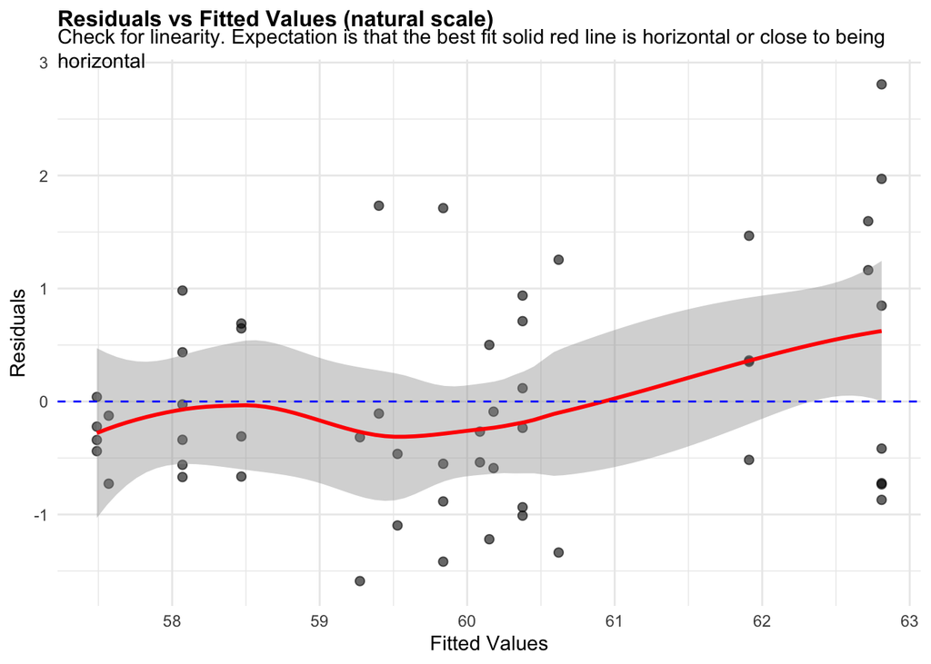

**Figure 94:** residuals_vs_fitted. Check for linearity (natural scale). Expectation is that the best fit solid red line is horizontal or close to being horizontal. Check the Residuals vs Fitted plots for good and bad examples here: https://library.virginia.edu/data/articles/diagnostic-plots

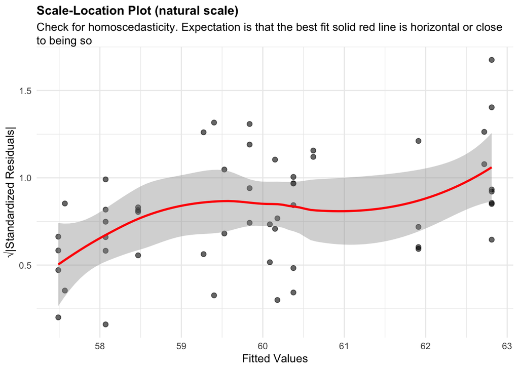

**Figure 95:** residuals_homoscedasticity. Check for homoscedasticity (natural scale). Expectation is that the best fit solid red line is horizontal or close to being so. Check the Scale-Location plots for good and bad examples here: https://library.virginia.edu/data/articles/diagnostic-plots

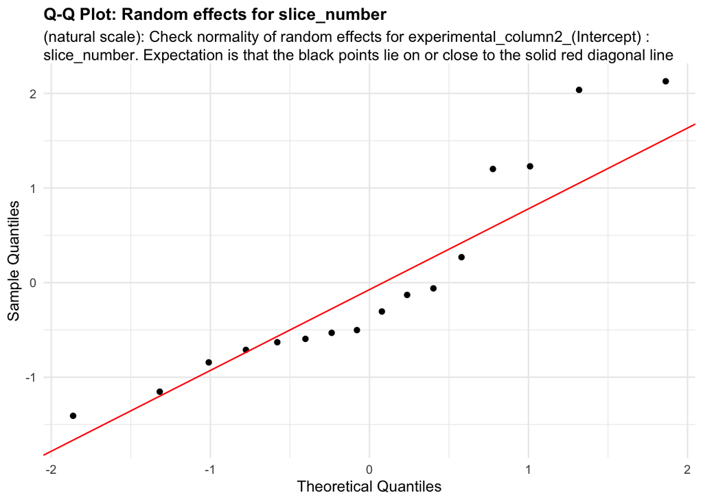

**Figure 96:** random_effects_QQ_1. Check normality of random effects for experimental_column2_(Intercept) (natural scale): slice_number. Expectation is that the black points lie on or close to the solid red diagonal line. Check the Normal Q-Q plots for good and bad examples here: https://library.virginia.edu/data/articles/diagnostic-plots

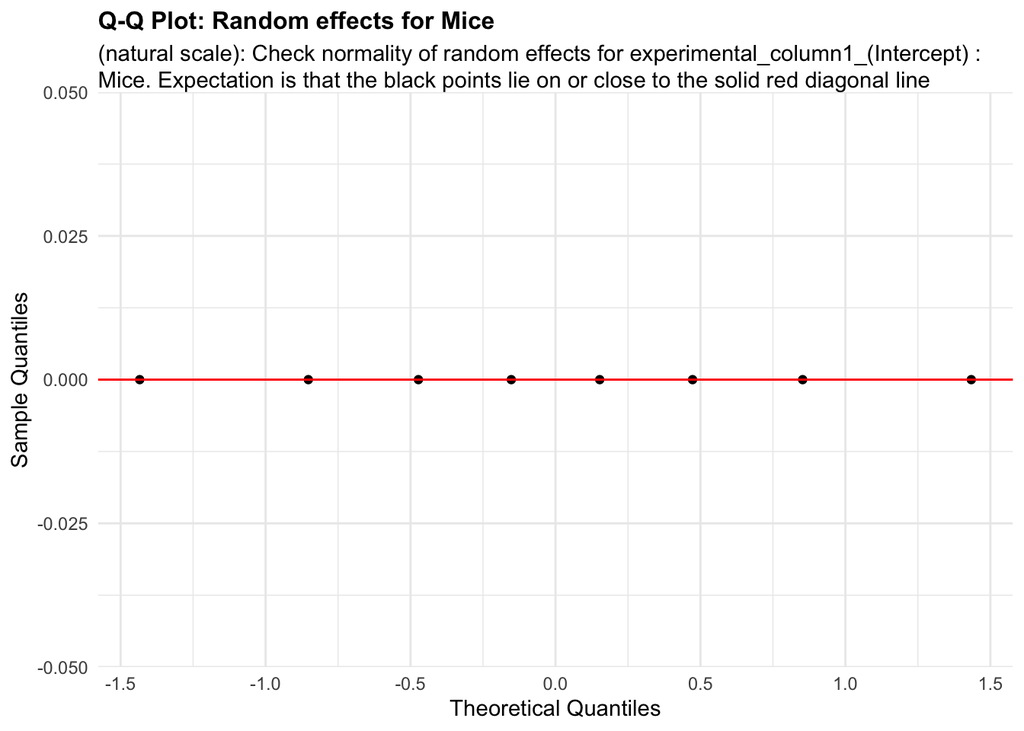

**Figure 97:** random_effects_QQ_2. Check normality of random effects for experimental_column1_(Intercept) (natural scale): Mice. Expectation is that the black points lie on or close to the solid red diagonal line. Check the Normal Q-Q plots for good and bad examples here: https://library.virginia.edu/data/articles/diagnostic-plots

```r
cooks_plots <- diagnose_res_update$cooks_plots$natural_scale
cat("\n\n\n")
```

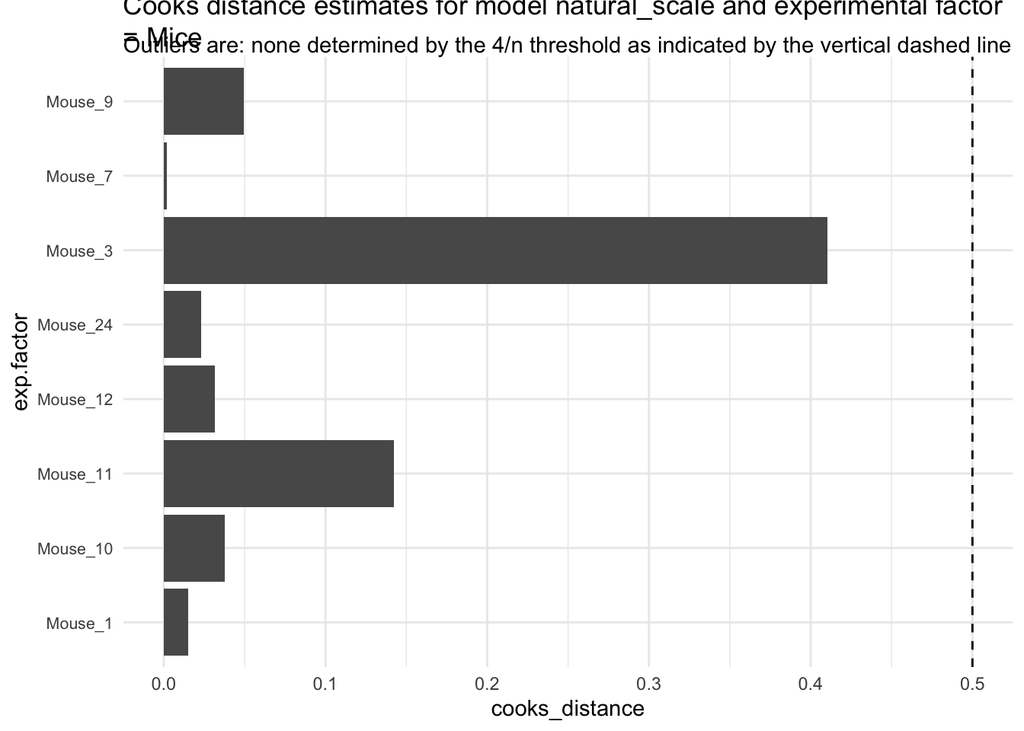

```r
for(i in 1:length(cooks_plots)) {
  print(cooks_plots[[i]])
  cat(sprintf("\n\n\n**Figure %d:**\n\n", plot_no))
  plot_no <- plot_no + 1
}
```

**Figure 98:**

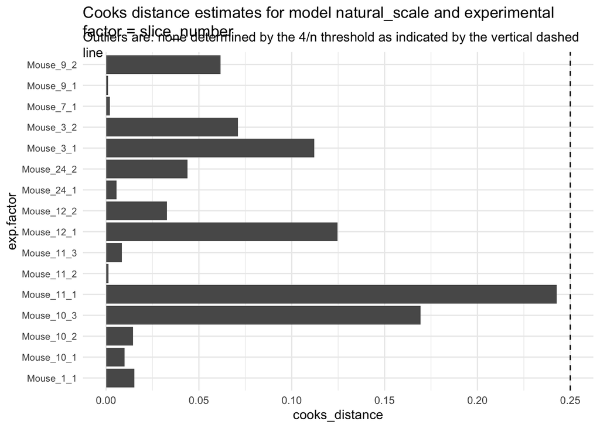

**Figure 99:**

```r
print("Inferred outlier groups are")
```

[1] “Inferred outlier groups are”

```r
print(diagnose_res$inferred_outlier_groups$natural_scale)
```

$Mice [1] “Mouse_2”

$slice_number [1] “Mouse_11_1”

Let us look the basic QC plots for the models fit in the log scale of the responses.

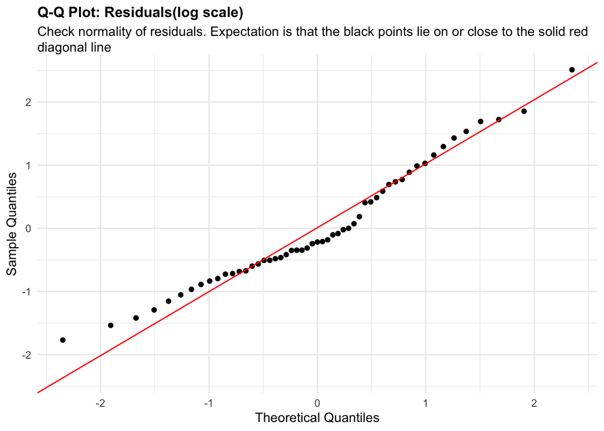

```r
plots <- diagnose_res_update$diagnostic_plots$log_scale$plots
captions <- diagnose_res_update$diagnostic_plots$log_scale$captions
for (i in seq_along(plots)) {
  print(plots[[i]])
    cat(sprintf("\n\n\n**Figure %d:** %s. %s\n\n", plot_no,names(plots)[i], captions[i]))
  plot_no <- plot_no + 1
}
```

**Figure 100:** residuals_QQ. Check normality of residuals (log scale). Expectation is that the black points lie on or close to the solid red diagonal line. Check the Normal Q-Q plots for good and bad examples here: https://library.virginia.edu/data/articles/diagnostic-plots

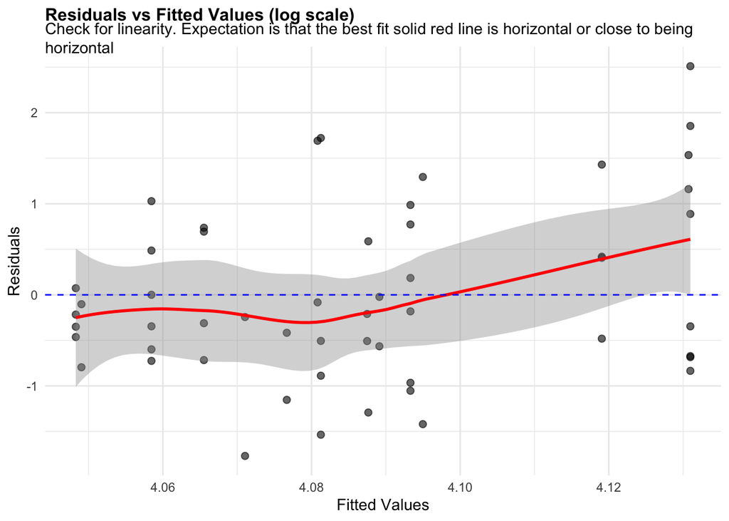

**Figure 101:** residuals_vs_fitted. Check for linearity (log scale). Expectation is that the best fit solid red line is horizontal or close to being horizontal. Check the Residuals vs Fitted plots for good and bad examples here: https://library.virginia.edu/data/articles/diagnostic-plots

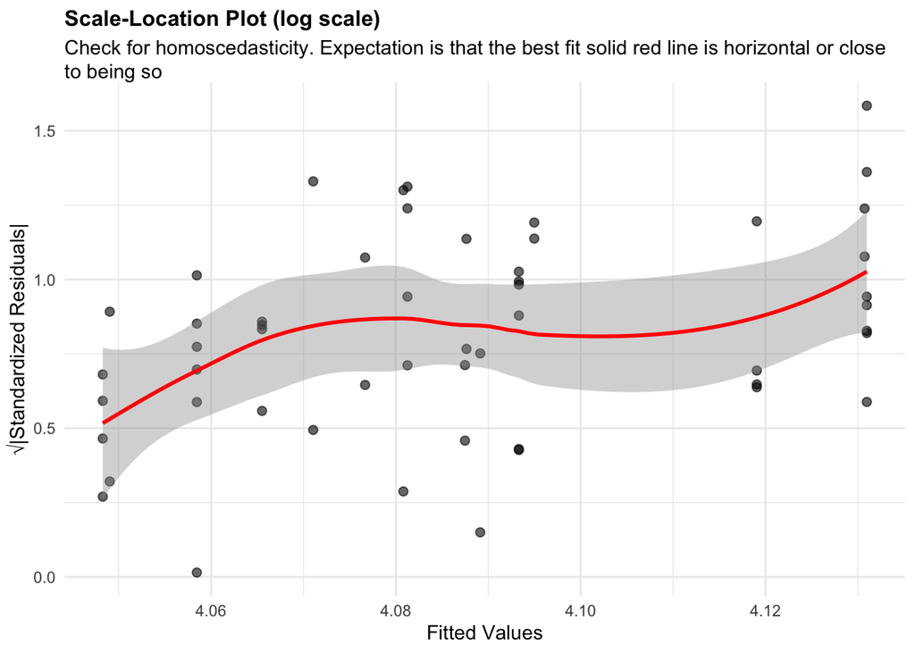

**Figure 102:** residuals_homoscedasticity. Check for homoscedasticity (log scale). Expectation is that the best fit solid red line is horizontal or close to being so. Check the Scale-Location plots for good and bad examples here: https://library.virginia.edu/data/articles/diagnostic-plots

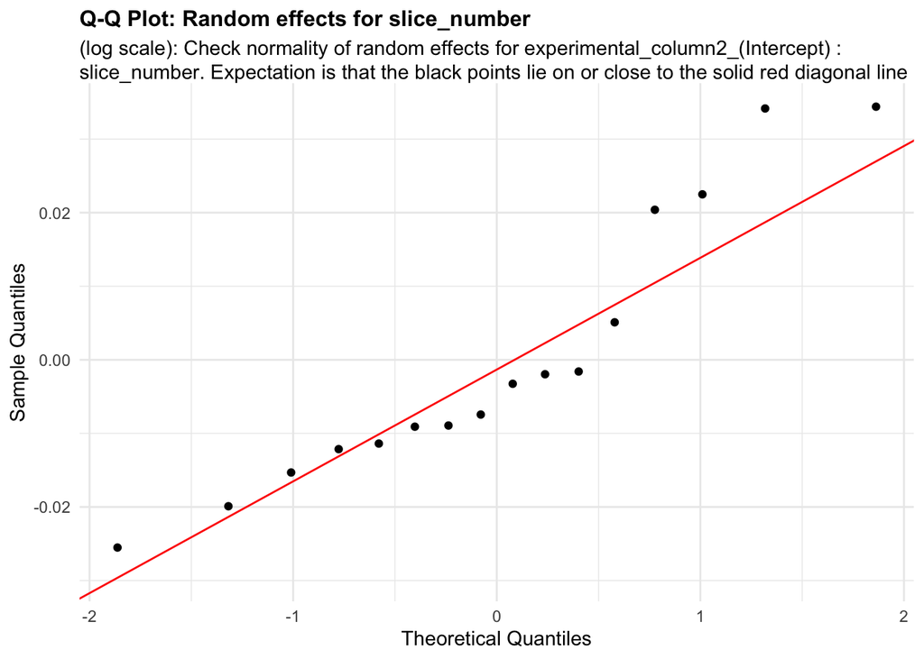

**Figure 103:** random_effects_QQ_1. Check normality of random effects for experimental_column2_(Intercept) (log scale): slice_number. Expectation is that the black points lie on or close to the solid red diagonal line. Check the Normal Q-Q plots for good and bad examples here: https://library.virginia.edu/data/articles/diagnostic-plots

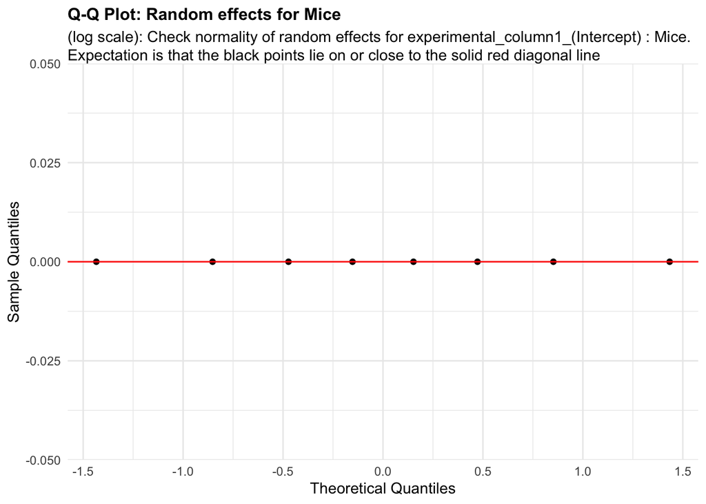

**Figure 104:** random_effects_QQ_2. Check normality of random effects for experimental_column1_(Intercept) (log scale): Mice. Expectation is that the black points lie on or close to the solid red diagonal line. Check the Normal Q-Q plots for good and bad examples here: https://library.virginia.edu/data/articles/diagnostic-plots

```r
cooks_plots <- diagnose_res_update$cooks_plots$log_scale
cat("\n\n\n")
```

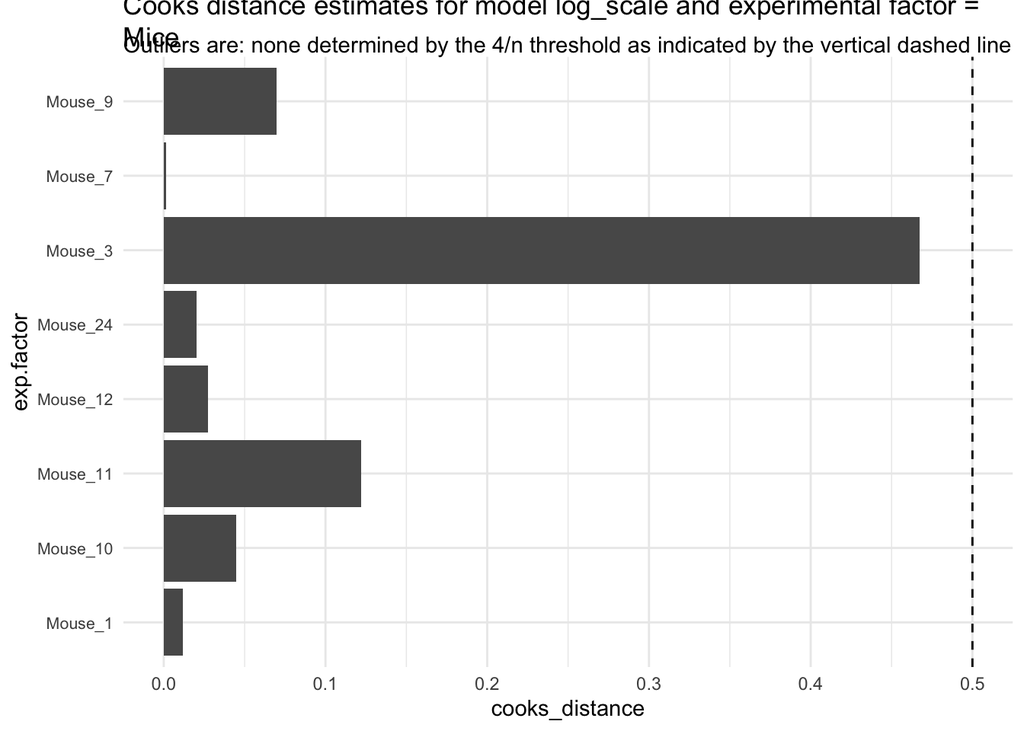

```r
for(i in 1:length(cooks_plots)) {
  print(cooks_plots[[i]])
  cat(sprintf("\n\n\n**Figure %d:**\n\n", plot_no))
  plot_no <- plot_no + 1
}
```

**Figure 105:**

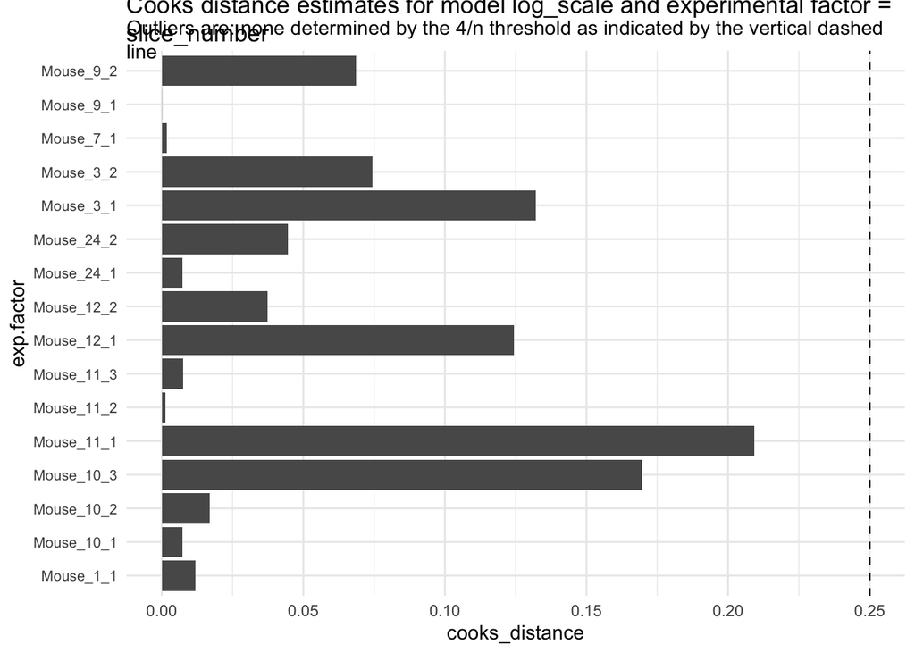

**Figure 106:**

```r
print("Inferred outlier groups are")
```

[1] “Inferred outlier groups are”

```r
print(diagnose_res$inferred_outlier_groups$natural_scale)
```

$Mice [1] “Mouse_2”

$slice_number [1] “Mouse_11_1”

It does not look like the log transformation resulted significantly changed how well the model assumptions were being met. We will estimate the association of genotype using the responses in their natural scale.

```
## Linear mixed model fit by REML. t-tests use Satterthwaite's method [
## lmerModLmerTest]
## Formula: response_column ~ condition_column + (1 | experimental_column1) +
##     (1 | experimental_column2)
##    Data: data.update
##
## REML criterion at convergence: 355.8
##
## Scaled residuals:
##     Min      1Q  Median      3Q     Max
## -1.5894 -0.6642 -0.2666  0.6472  2.8072
##
## Random effects:
##  Groups               Name        Variance Std.Dev.
##  experimental_column2 (Intercept)  5.288   2.300
##  experimental_column1 (Intercept)  0.000   0.000
##  Residual                         51.232   7.158
## Number of obs: 53, groups:  experimental_column2, 16; experimental_column1, 8
##
## Fixed effects:
##                    Estimate Std. Error     df t value Pr(>|t|)
## (Intercept)          60.681      1.431 10.601  42.419 3.53e-13 ***
## condition_columnWT   -2.481      2.467  9.736  -1.006    0.339
## ---
## Signif. codes:  0 '***' 0.001 '**' 0.01 '*' 0.05 '.' 0.1 ' ' 1
##
## Correlation of Fixed Effects:
##             (Intr)
## cndtn_clmWT -0.580
## optimizer (nloptwrap) convergence code: 0 (OK)
## boundary (singular) fit: see help('isSingular')
```

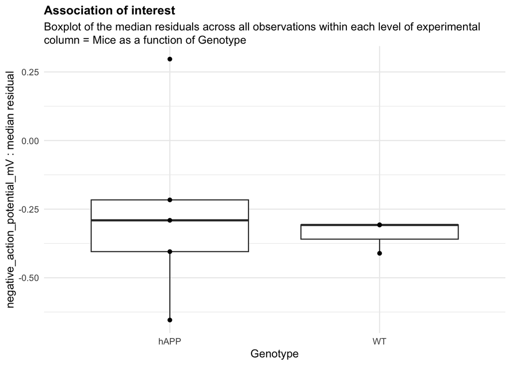

```r
estimate_res <- getEstimatesOfInterest(data_update, design, model, print_plots = F)
print(estimate_res[[1]])
```

**Figure 107:**

This is not significant at all. How many mice do we need to have 80% power to estimate the observed difference? We will also try and specify a larger effect size we want to detect. Note, this is specified by a 3-dimensional numeric vector. The first element reflects the change associated with the `condition_column`, the second with the `covariate` while the third element with the interaction effect if specified. When there is no `covariate` or `include_interaction` specified the corresponding elements of this `effect_size` vector is set to NA.

```r
power_param@target_columns <- "Mice"
power_param@effect_size <- c(-7, NA, NA)
power_res <- calculatePower(data, design, model, power_param)
```

[[1]]

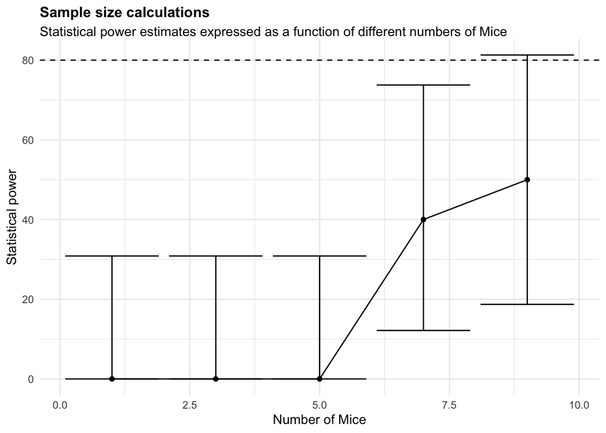

**Figure 108:**

```r
power_param@target_columns <- "slice_number"
power_res_slice <- calculatePower(data, design, model, power_param)
```

[[1]]

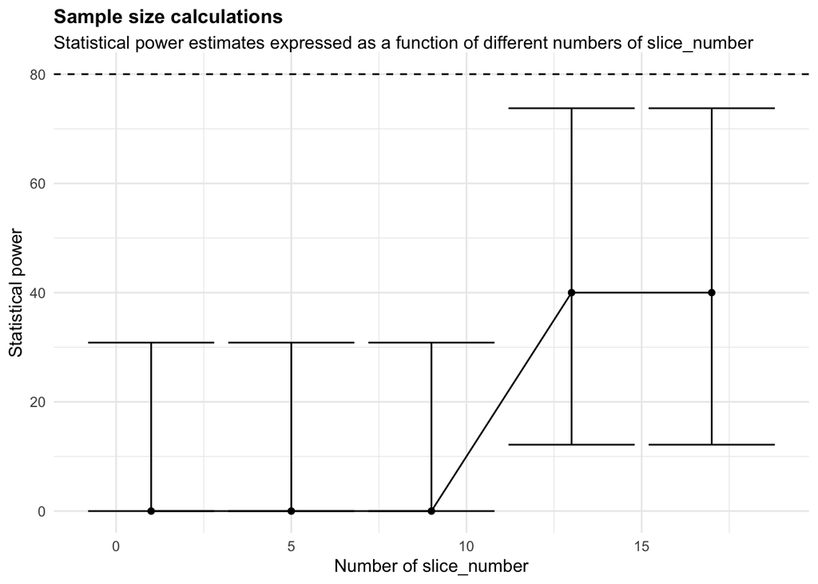

**Figure 109:**

# 3 Understanding simulations to estimate the power

`RMeDPower2` is designed to simulate the effect of variability of the responses which could come from differences in the processing batch, plates or cell lines on the responses of interest the cell assay data (described above for exampel). There are several ways to assess the impact of different choices for the experimental variables in this package as outlined below.

First, a user can assess how increasing the number of independent experiments affects power. For example, if a user has a pilot dataset that consists of 3 experimental batches that each contain 2 plates, expanding this dataset two-fold would have the effect of simulating 6 experiments with a total of 12 plates (Figure 110).

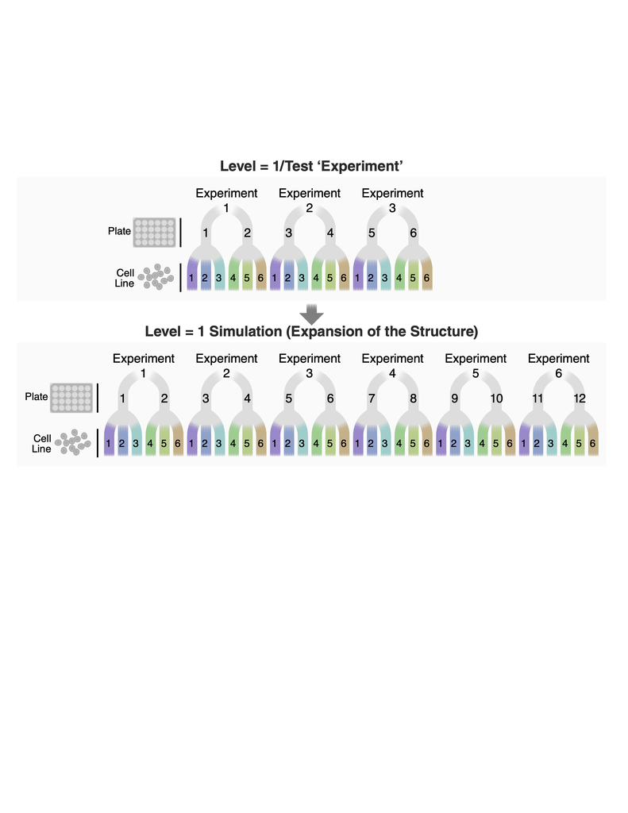

**Figure 110:** Example of RMeDPower’s simulation of experimental variability for ‘experiment’ for the power analysis. If level=1 is set, RMeDPower simulates the effect of adding in additional experiments by inheriting the experimental design structure from the existing data. This describes the situation where the pilot study involves data from 3 experiments, with 2 plates used per experiment, 3 cell lines within each plate and 12 cells per cell line are assayed.

```r
template_dir <- system.file("input_templates/understanding_simulations",
                            package = "RMeDPower2")

##load the design
design <- readDesign(file.path(template_dir, "design_cell_assay_sim1.json"))
##load the probability model
model <- readProbabilityModel(file.path(template_dir, "prob_model_sim1.json"))
##load the relevant power parameters
power_param <- readPowerParams(file.path(template_dir, "power_param_sim1.json"))

##filter out the top 5% of observations
plate_assay_pilot_data %<>% filter(cell_size2 < quantile(cell_size2, 0.95))

print(design)
```

```
## An object of class "RMeDesign"
## Slot "response_column":
## [1] "cell_size2"
##
## Slot "covariate":
## NULL
##
## Slot "condition_column":
## [1] "classification"
##
## Slot "condition_is_categorical":
## [1] TRUE
##
## Slot "experimental_columns":
## [1] "experiment" "line"
##
## Slot "crossed_columns":
## [1] "line"
##
## Slot "total_column":
## NULL
##
## Slot "outlier_alpha":
## [1] 0.05
##
## Slot "na_action":
## [1] "complete"
##
## Slot "include_interaction":
## [1] NA
##
## Slot "random_slope_variable":
## NULL
##
## Slot "covariate_is_categorical":
## [1] NA
```

```r
print(model)
```

```
## An object of class "ProbabilityModel"
## Slot "error_is_non_normal":
## [1] FALSE
##
## Slot "family_p":
## NULL
```

```r
print(power_param)
```

```
## An object of class "PowerParams"
## Slot "target_columns":
## [1] "experiment"
##
## Slot "power_curve":
## [1] 1
##
## Slot "nsimn":
## [1] 10
##
## Slot "levels":
## [1] 1
##
## Slot "max_size":
## NULL
##
## Slot "alpha":
## [1] 0.05
##
## Slot "breaks":
## NULL
##
## Slot "effect_size":
## NULL
##
## Slot "icc":
## NULL
```

The first step involves running a diagnosis of the data and the model.

```r
diagnose_res <- diagnoseDataModel(plate_assay_pilot_data, design, model)
design_update <- design
data_update <- diagnose_res$Data_updated
print(colnames(data_update))
```

```
##  [1] "cell_size2_logTransformed_noOutlier" "cell_size2_logTransformed"
##  [3] "cell_size2_noOutlier"                "experiment"
##  [5] "line"                                "classification"
##  [7] "cell_size1"                          "cell_size2"
##  [9] "cell_size3"                          "cell_size4"
## [11] "cell_size5"                          "cell_size6"
```

```r
design_update@response_column <-  "cell_size2_logTransformed"
```

We can now perform sample-size estimations for the effects of increasing the number of experimental batches.

```r
##calculate power
power_res <- calculatePower(data_update, design_update, model, power_param)
```

[[1]]

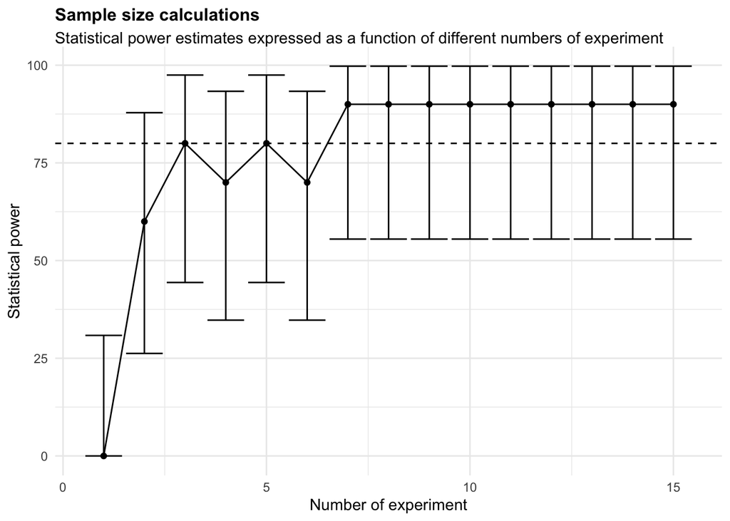

**Figure 111:**

In a similar context, users can evaluate power for a given number of experiments. To do this, we assign a value corresponding to the number of experiments to max_size and set ‘power_curve’ to 0. We can set the ‘output’ variable to specify the output file name.

```r
template_dir <- system.file("input_templates/understanding_simulations",
                            package = "RMeDPower2")

##load the relevant power parameters
power_param <- readPowerParams(file.path(template_dir, "power_param_sim3.json"))

print(power_param)
```

```
## An object of class "PowerParams"
## Slot "target_columns":
## [1] "experiment"
##
## Slot "power_curve":
## [1] 0
##
## Slot "nsimn":
## [1] 10
##
## Slot "levels":
## [1] 1
##
## Slot "max_size":
## [1] 15
##
## Slot "alpha":
## [1] 0.05
##
## Slot "breaks":
## NULL
##
## Slot "effect_size":
## NULL
##
## Slot "icc":
## NULL
```

```r
##calculate power
power_res <- calculatePower(data_update, design_update, model, power_param)
```

```
## Power for predictor 'condition_column', (95% confidence interval):
##       90.00% (55.50, 99.75)
##
## Test: Likelihood ratio
##
## Based on 10 simulations, (0 errors, 0 warnings, 0 messages)
##
## Time elapsed: 0 h 0 m 2 s
##
## nb: result might be an observed power calculation
```

```r
set.seed(12345)
##observed differences of means = 0.03072
power_param@max_size <- 8
power_param@target_columns <- "experiment"
power_param@levels <- 1
power_param@power_curve <- 0
power_param@effect_size <- c(0.03072, NA, NA)
calculatePower(data_update, design_update, model, power_param)
```

```
## Power for predictor 'condition_column', (95% confidence interval):
##       90.00% (55.50, 99.75)
##
## Test: Likelihood ratio
##
## Based on 10 simulations, (0 errors, 0 warnings, 0 messages)
##
## Time elapsed: 0 h 0 m 1 s
```

```r
set.seed(12345)
##asssumed difference of means = 0.02
power_param@max_size <- 8
power_param@target_columns <- "experiment"
power_param@levels <- 1
power_param@power_curve <- 0
power_param@effect_size <- c(0.02, NA, NA)
calculatePower(data_update, design_update, model, power_param)
```

```
## Power for predictor 'condition_column', (95% confidence interval):
##       80.00% (44.39, 97.48)
##
## Test: Likelihood ratio
##
## Based on 10 simulations, (0 errors, 0 warnings, 0 messages)
##
## Time elapsed: 0 h 0 m 1 s
```

We can also test the power of two experimental variables by assigning a vector of variable names to ‘target_columns’.

```r
power_param <- readPowerParams(file.path(template_dir,"power_param_sim5.json"))

print(power_param)
```

```
## An object of class "PowerParams"
## Slot "target_columns":
## [1] "experiment" "line"
##
## Slot "power_curve":
## [1] 1
##
## Slot "nsimn":
## [1] 10
##
## Slot "levels":
## [1] 1 0
##
## Slot "max_size":
## [1]   9 142
##
## Slot "alpha":
## [1] 0.05
##
## Slot "breaks":
## NULL
##
## Slot "effect_size":
## NULL
##
## Slot "icc":
## NULL
```

```r
##calculate power
power_res <- calculatePower(data_update, design_update, model, power_param)
```

[output not shown]

Our power simulations depend on the variance components estimated from the input dataset. However, in some cases there may not be enough data to estimate the variance component. For example, the pilot data might have only a single category for ‘experimental batch’, ‘plate’ or ‘line’. When this occurs, the user needs to provide ICC values. These values can be estimated from another dataset for which the variance components are assumed to be similar to those inherent for the new response being considered in the input dataset. ICC can be estimated by taking the ratio between the variance estimates using the following formula:

$$ICC_i=\frac{V_i}{∑_{j∈S}V_i+e}$$
where V_i represents the variance of the random effect linked to experimental variable (e.g., experimental batch, plate or cell-line) i, and epsilon represents the variance of the residual error. S represents all the modeled sources of variability of the response under consideration. We will test this scenario using the example RMeDPower_data2 with only single experiment and cell line. To test power in scenarios with varying number of experiments, we set the ‘icc’ parameter to 0.8, 0.05, 0.05.

```r
template_dir <- system.file("input_templates/understanding_simulations",
                            package = "RMeDPower2")

##load the design
design <- readDesign(file.path(template_dir, "design_cell_assay_sim6.json"))
##load the probability model
model <- readProbabilityModel(file.path(template_dir, "prob_model_sim6.json"))
##load the relevant power parameters
power_param <- readPowerParams(file.path(template_dir, "power_param_sim6.json"))

#print(design)
#print(model)
print(power_param)
```

```
## An object of class "PowerParams"
## Slot "target_columns":
## [1] "experiment"
##
## Slot "power_curve":
## [1] 1
##
## Slot "nsimn":
## [1] 10
##
## Slot "levels":
## [1] 1
##
## Slot "max_size":
## NULL
##
## Slot "alpha":
## [1] 0.05
##
## Slot "breaks":
## NULL
##
## Slot "effect_size":
## NULL
##
## Slot "icc":
## [1] 0.80 0.05 0.05
```

```r
##calculate power
power_res <- calculatePower(plate_assay_pilot_data_wo_repeats, design, model, power_param)
```

[output not shown]

Alternatively, a user can assess how increasing the number of plates per experiment affects power. In the case where there are two experiments that each contain two plates, the user can double the number of plates used per experiment. In this way, the user can simulate how the statistical power changes as a result of increasing the number of plates used per experiment rather than increasing the number of experimental batches (Figure 112).

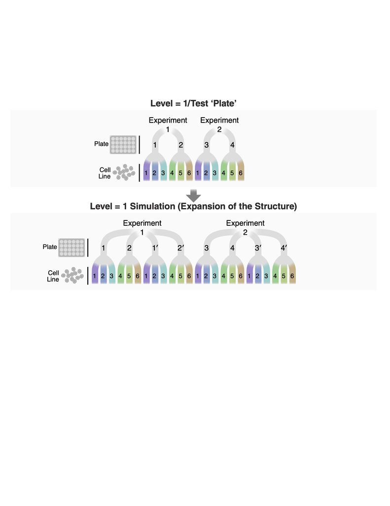

**Figure 112:** Example of RMeDPower’s simulation of plate variability for ‘plate’ power analysis. If level=1 is set, RMeDPower simulates new plates by inheriting the experimental design structure from the existing data.

In a third example, a user can examine the effect of expanding the number of cell lines within each experiment affects power (Figure 113). This would capture the effect of increasing the number of cells assayed as a consequence of having more cell lines.

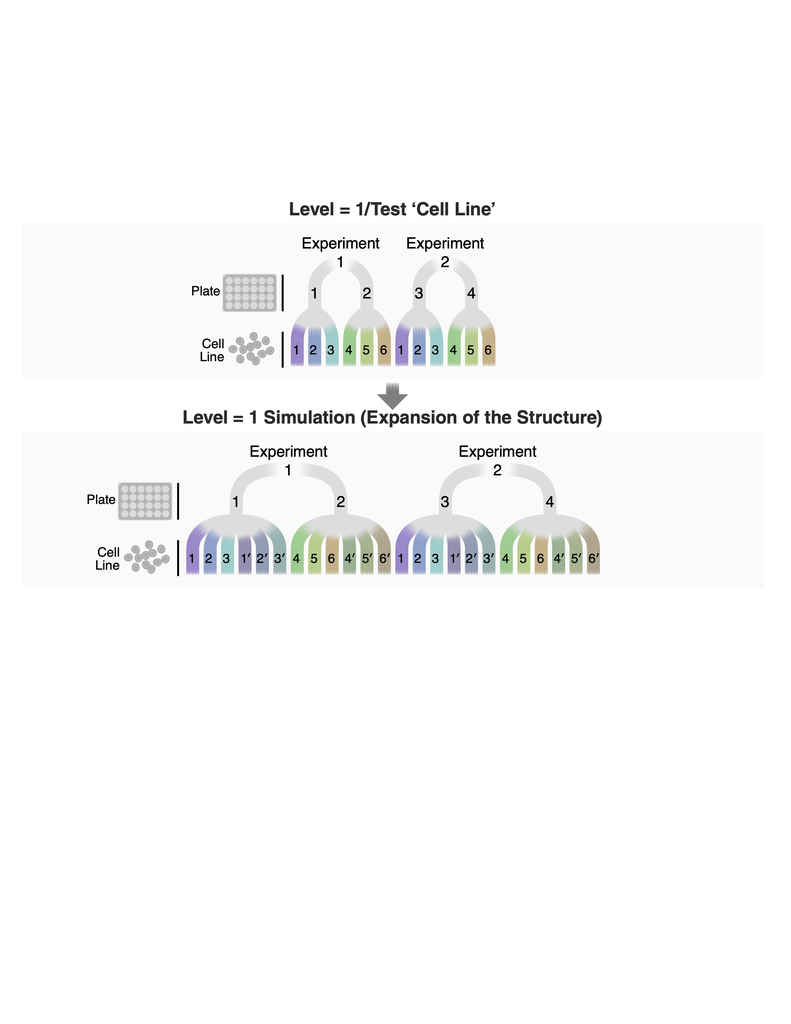

**Figure 113:** Example of RMeDPower’s simulation of cell line variability for ‘cell line’ power analysis. If level=1 is set, RMeDPower simulates new cell lines by inheriting the experimental design structure from the existing data.

Alternatively, one might want to assess the effect of increasing the total number of cells by increasing the number of cells per cell line (Figure 114).

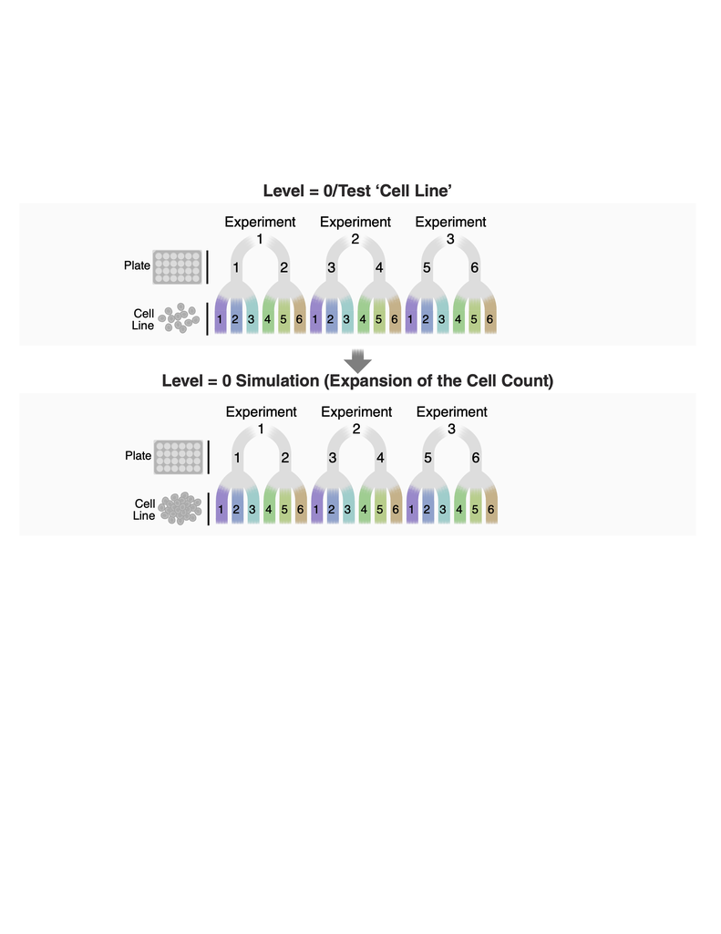

Tables 1-3, in addition to the figures, show the change in cell number after variable expansion in experiment, plate or cell line, especially when the cell distribution is asymmetric. A user may want to examine the power of increasing the total number of cells measured from each experimental variable per experiment. For example, if there are 12 cells per cell line on plate 1, doubling the number of cells from each plate will result in assessing the effect in twice the number of cells per cell line, even if the number of experiments and cell lines remain the same (Figure 115).

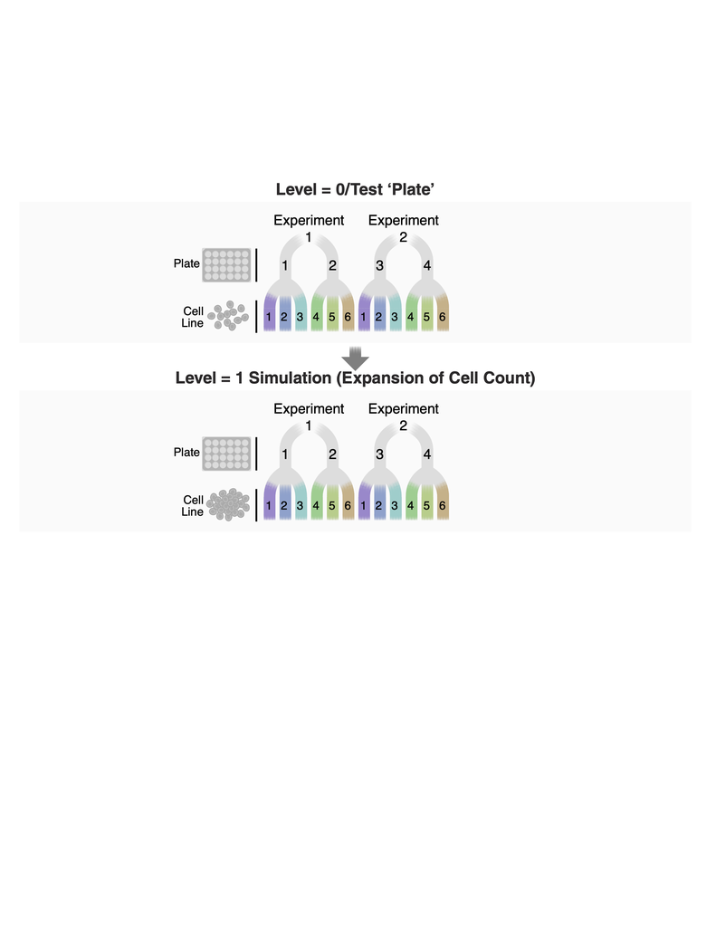

**Figure 115:** Example of RMeDPower’s simulation of a sample size increase for ‘plate’ power analysis. If level=0 is set, RMeDPower multiplies the number of cells per plate by M/N, where N is the maximum number of cells per plate and M is a value assigned to the parameter maxsize.

| (A) | Cell line 1 | Cell line 2 |
| --- | --- | --- |
| Exp 1 | 3 | 6 |
| Exp 2 | 3 | 0 |
| (B) | Cell line 1 | Cell line2 |
| Exp 1 | 3 | 6 |
| Exp 2 | 3 | 0 |
| Exp 3 | 3 | 6 |
| Exp 4 | 3 | 0 |

Example of changes in cell counts in a simulation of plate variability. (A) Original data structure and (B) changed data structure after simulation. Simulation based on level=1 keeps the same structure and increases the number of plates.

| (A) | Cell line 1 | Cell line 2 |
| --- | --- | --- |
| Plate 1 | 4 | 5 |
| Plate 2 | 2 | 0 |
| (B) | Cell line 1 | Cell line 2 |
| Plate 1 | 4 | 5 |
| Plate 2 | 2 | 0 |
| Plate 1’ | 4 | 5 |
| Plate 2’ | 2 | 0 |

Example of changes in cell counts in a simulation of cell line variability. (A) Original data structure and (B) changed data structure after simulation. If level=1 is set, RMeDPower simulates new cell lines by inheriting the experimental design structure from the existing data. An example of a simulation in tabular format shows the change in the number of cells per cell line and experiment after simulation. Simulation based on level=1 keeps the same structure and increases the number of cell lines.

| (A) | Cell line 1 | Cell line 2 |  |  |  |  |
| --- | --- | --- | --- | --- | --- | --- |
| Exp 1 | 3 | 6 |  |  |  |  |
| Exp 2 | 3 | 0 |  |  |  |  |
| (B) | Cell line 1a | Cell line 2a | Cell line 1b | Cell line 2b | Cell line 1c | Cell line 2c |
| Exp 1 | 3 | 6 | 3 | 6 | 3 | 6 |
| Exp 2 | 3 | 0 | 3 | 0 | 3 | 0 |

Expansion results for plates and cell lines may differ if cells are asymmetrically distributed in different settings. Tables 4 and 5 show the different results users can get in an asymmetric distributed cell scenario. This type of variable expansion can be accomplished by setting ‘level=0’ in the calculate_power function.

Example of plate-based cell count expansion simulation. (A) Original data structure and (B) changed data structure after simulation. The simulation is based on level=0 which results in increased number of cells per plate.

| (A) | Cell line 1 | Cell line2 |
| --- | --- | --- |
| Plate 1 | 3 | 6 |
| Plate 2 | 3 | 0 |
| (B) | Cell line 1 | Cell line 2 |
| Plate 1 | 6 | 12 |
| Plate 2 | 6 | 0 |

Example of cell line-based cell count expansion simulation. (A) Original data structure and (B) changed data structure after simulation. An example of a simulation in tabular format shows the change in the number of cells per cell line and experiment after simulation. The simulation is based on level=0 which results in an increased number of cells per cell line.

| (A) | Cell line 1 | Cell line 2 |
| --- | --- | --- |
| Exp 1 | 3 | 6 |
| Exp 2 | 3 | 0 |
| (B) | Cell line 1 | Cell line 2 |
| Exp 1 | 9 | 18 |
| Exp 2 | 9 | 0 |